# Leidys Margarita Valencia Bello - Especialización en Machine Learning - Programación para la Ciencia de datos

Cada grupo entregará su cuadernillo en formato HTML mostrando el desarrollo del proyecto integrador con su respectivo estudio del mercado en el sector público. Se espera que haya un proceso de desarrollo del código donde se tomen dos Dataframe, se limpien sus variables, se crucen y se visualicen las variables de interés.

## Productos:

Los grupos deben entregar un documento HTML contenga lo siguiente:

1. Instalación de paquetes
2. Importe de las librerias necesarias
3. Carga de las bases de datos
4. Análisis exploratorio de las variables
5. Cruce de bases
6. Filtro de bases
7. Graficicación de las variables
8. Análisis del sector económico
9. Visualización de las variables y comentarios de los observado

## Instrucciones:

Los grupos deben entregar un cuadernillo de Jupyter en formato HTML, donde se describa el análisis de un sector de contratación en el sector público.

Se evaluará en el documento HTML que entregue cada grupo lo siguiente

## Resultados

### 1. Instalación de paquetes

Se inicia con la instalación de la libreria pandas, para la respectiva carga de los archivos necesarios.

```python
pip install pandas
```

### 2. Importe de las librerías necesarias

Se importa la librería 'pandas' que es la principal herramienta de manipulación y análisis de datos Python. Con 'pandas', es posible cargar archivos csv, combinarlos y analizarlos como se hará a continuación

```python
import pandas as pd
```

### 3. Carga de las bases de datos

Aquí se especifican las rutas de los archivos 'Orders.csv' y Details.csv', luego, se utiliza 'pd.read_csv()' para leer esos archivos y cargarlos en dataframes 'orders_df' y 'details_df', que son estructuras de datos tabulares que 'pandas' utiliza para trabajar con los datos.

```python
# Se cargan los archivos CSV
orders_path = 'Orders.csv'
details_path = 'Details.csv'

# Se leen los datasets
orders_df = pd.read_csv(orders_path)
details_df = pd.read_csv(details_path)

# Se muestran las primeras filas de ambos dataframes para ver sus contenidos
orders_df.head(), details_df.head()
```

```
(  Order ID  Order Date CustomerName           State     City
 0  B-26055  10-03-2018    Harivansh   Uttar Pradesh  Mathura
 1  B-25993  03-02-2018       Madhav           Delhi    Delhi
 2  B-25973  24-01-2018  Madan Mohan   Uttar Pradesh  Mathura
 3  B-25923  27-12-2018        Gopal     Maharashtra   Mumbai
 4  B-25757  21-08-2018     Vishakha  Madhya Pradesh   Indore,
   Order ID  Amount  Profit  Quantity     Category      Sub-Category  \
 0  B-25681    1096     658         7  Electronics  Electronic Games
 1  B-26055    5729      64        14    Furniture            Chairs
 2  B-25955    2927     146         8    Furniture         Bookcases
 3  B-26093    2847     712         8  Electronics          Printers
 4  B-25602    2617    1151         4  Electronics            Phones

    PaymentMode
 0          COD
 1          EMI
 2          EMI
 3  Credit Card
 4  Credit Card  )
```

Ya se encuentran cargados ambos archivos csv ('Orders.csv' y Details.csv') en Python para comenzar a trabajar con ellos. Ahora se tienen los datos de ventas en línea y los detalles de las órdenes disponibles.

### 4. Análisis exploratorio de las variables

Se inicia por conocer y visualizar las primeras filas del dataframe 'orders_df'

```python
print(orders_df.head())
```

```
  Order ID  Order Date CustomerName           State     City
0  B-26055  10-03-2018    Harivansh   Uttar Pradesh  Mathura
1  B-25993  03-02-2018       Madhav           Delhi    Delhi
2  B-25973  24-01-2018  Madan Mohan   Uttar Pradesh  Mathura
3  B-25923  27-12-2018        Gopal     Maharashtra   Mumbai
4  B-25757  21-08-2018     Vishakha  Madhya Pradesh   Indore
```

Las primeras filas dan una idea general de cómo están organizados los datos, así como los valores de las variables clave, como 'Order ID', 'Order Date', 'CustomerName', 'State' y 'City'

'info()' muestra la cantidad de filas, el tipo de datos de cada columna y si hay valores faltantes en el dataframe 'orders_df'

```python
print(orders_df.info())
```

```
<class 'pandas.core.frame.DataFrame'>
RangeIndex: 500 entries, 0 to 499
Data columns (total 5 columns):
 #   Column        Non-Null Count  Dtype
---  ------        --------------  -----
 0   Order ID      500 non-null    object
 1   Order Date    500 non-null    object
 2   CustomerName  500 non-null    object
 3   State         500 non-null    object
 4   City          500 non-null    object
dtypes: object(5)
memory usage: 19.7+ KB
None
```

Se observa el tipo de dato de cada variable y la cantidad de valores nulos

'describe()' muestra las estadísticas descriptivas como el conteo, media, desviación estándar, mínimo, máximo y cuartiles de las variables númericas.

```python
print(orders_df.describe())
```

```
       Order ID  Order Date CustomerName        State    City
count       500         500          500          500     500
unique      500         307          336           19      25
top     B-26055  24-11-2018       Shreya  Maharashtra  Indore
freq          1           7            6           94      71
```

Se continua por conocer y visualizar las primeras filas del dataframe 'details_df'

```python
print(details_df.head())
```

```
  Order ID  Amount  Profit  Quantity     Category      Sub-Category  \
0  B-25681    1096     658         7  Electronics  Electronic Games
1  B-26055    5729      64        14    Furniture            Chairs
2  B-25955    2927     146         8    Furniture         Bookcases
3  B-26093    2847     712         8  Electronics          Printers
4  B-25602    2617    1151         4  Electronics            Phones

   PaymentMode
0          COD
1          EMI
2          EMI
3  Credit Card
4  Credit Card
```

Las primeras filas dan una idea general de cómo están organizados los datos, así como los valores de las variables clave relacionadas con los productos y las transacciones

'info()' muestra la cantidad de filas, el tipo de datos de cada columna y si hay valores faltantes en el dataframe 'details_df'

```python
print(details_df.info())
```

```
<class 'pandas.core.frame.DataFrame'>
RangeIndex: 1500 entries, 0 to 1499
Data columns (total 7 columns):
 #   Column        Non-Null Count  Dtype
---  ------        --------------  -----
 0   Order ID      1500 non-null   object
 1   Amount        1500 non-null   int64
 2   Profit        1500 non-null   int64
 3   Quantity      1500 non-null   int64
 4   Category      1500 non-null   object
 5   Sub-Category  1500 non-null   object
 6   PaymentMode   1500 non-null   object
dtypes: int64(3), object(4)
memory usage: 82.2+ KB
None
```

En este análisis se pueden observar los tipos de variables como por ejemplo 'object', 'int64'. Además también se muestra la cantidad de valores Non o Null en cada variable

Se continua con 'df.describe() para obtener estadísticas descriptivas de las variables numéricas, como el monto de la venta, el beneficio y la cantidad de productos.

```python
print(details_df.describe())
```

```
            Amount      Profit     Quantity
count  1500.000000  1500.00000  1500.000000
mean    291.847333    24.64200     3.743333
std     461.924620   168.55881     2.184942
min       4.000000 -1981.00000     1.000000
25%      47.750000   -12.00000     2.000000
50%     122.000000     8.00000     3.000000
75%     326.250000    38.00000     5.000000
max    5729.000000  1864.00000    14.000000
```

### 5. Cruce de bases

A continuación se procede a utilizar la función 'pd.merge()' para combinar los dos dataframes ('orders_df' y 'details_df') en uno solo. La columna 'Order ID' es la clave que se utiliza para identificar las filas correspondientes en ambos archivos. El tipo de combinación es 'inner', lo que significa que solo las filas que tienen 'Order ID' presente en ambos dataframes serán incluidas en el resultado final.

```python
# Realizar un merge de los dataframes en la columna 'Order ID'
merged_df = pd.merge(orders_df, details_df, on='Order ID', how='inner')

# Mostrar las primeras filas del dataframe combinado
print(merged_df.head())
```

```
  Order ID  Order Date CustomerName          State     City  Amount  Profit  \
0  B-26055  10-03-2018    Harivansh  Uttar Pradesh  Mathura    5729      64
1  B-26055  10-03-2018    Harivansh  Uttar Pradesh  Mathura     671     114
2  B-26055  10-03-2018    Harivansh  Uttar Pradesh  Mathura     443      11
3  B-26055  10-03-2018    Harivansh  Uttar Pradesh  Mathura      57       7
4  B-26055  10-03-2018    Harivansh  Uttar Pradesh  Mathura     227      48

   Quantity     Category Sub-Category  PaymentMode
0        14    Furniture       Chairs          EMI
1         9  Electronics       Phones  Credit Card
2         1     Clothing        Saree          COD
3         2     Clothing        Shirt          UPI
4         5     Clothing        Stole          COD
```

En este paso, se verifico que los datos de ventas en línea se hayn unido correctamente. Se pueden ver los detalles de los clientes y las órdenes, como cantidades, categorías y modos de pago, en una sola vista.

Una vez se ha realizado el cruce de la bases de datos se procede a realizar un análisis exploratorio de los datos en conjunto

```python
print(merged_df.info())
```

```
<class 'pandas.core.frame.DataFrame'>
RangeIndex: 1500 entries, 0 to 1499
Data columns (total 11 columns):
 #   Column        Non-Null Count  Dtype
---  ------        --------------  -----
 0   Order ID      1500 non-null   object
 1   Order Date    1500 non-null   object
 2   CustomerName  1500 non-null   object
 3   State         1500 non-null   object
 4   City          1500 non-null   object
 5   Amount        1500 non-null   int64
 6   Profit        1500 non-null   int64
 7   Quantity      1500 non-null   int64
 8   Category      1500 non-null   object
 9   Sub-Category  1500 non-null   object
 10  PaymentMode   1500 non-null   object
dtypes: int64(3), object(8)
memory usage: 129.0+ KB
None
```

Se ha validado que la combinación de los dataframes se realizó de forma correcta y que se tiene la información de cada 'Order ID' que coincide

Se continua con el análisis de estadísticas descriptivas de las variables númericas, como 'Amount', 'Profit' y 'Quantify'

```python
print(merged_df.describe())
```

```
            Amount      Profit     Quantity
count  1500.000000  1500.00000  1500.000000
mean    291.847333    24.64200     3.743333
std     461.924620   168.55881     2.184942
min       4.000000 -1981.00000     1.000000
25%      47.750000   -12.00000     2.000000
50%     122.000000     8.00000     3.000000
75%     326.250000    38.00000     5.000000
max    5729.000000  1864.00000    14.000000
```

Se observa el rango de valores para las ventas, los beneficios y la cantidad de productos por orden.

Se continua con 'value_counts()' para conocer cuántas veces aparece cada categoría, estado y método de pago en el dataframe combinado.

```python
print(merged_df['Category'].value_counts())
print(merged_df['State'].value_counts())
print(merged_df['PaymentMode'].value_counts())
```

```
Category
Clothing       949
Electronics    308
Furniture      243
Name: count, dtype: int64
State
Madhya Pradesh       314
Maharashtra          299
Uttar Pradesh         87
Gujarat               87
Delhi                 76
Rajasthan             74
West Bengal           63
Bihar                 62
Punjab                60
Karnataka             50
Jammu and Kashmir     49
Kerala                45
Nagaland              45
Goa                   43
Andhra Pradesh        42
Himachal Pradesh      29
Haryana               26
Tamil Nadu            25
Sikkim                24
Name: count, dtype: int64
PaymentMode
COD            684
UPI            331
Debit Card     202
Credit Card    163
EMI            120
Name: count, dtype: int64
```

En este pado se pudo observar la distribución de los datos categóricos. Por ejemplo, se visualizan cuáles son las categorías más vendidas, en qué estados se realizan más compras y cuál es el método de pago más común.

Los resultados fueron:

- Category clothing igual a 949
- State Madhya Pradesh igual a 314
- PaymentMode COD igual a 684

### 6. Filtro de bases

Filtrar las órdenes con un monto mayor a 3,000: Este Filtro permitirá identificar las órdenes de alto valor que podrían ser representativas de grandes transacciones o clientes importantes.

```python
high_value_orders = merged_df[merged_df['Amount'] > 3000]
print(high_value_orders.head(5))
```

```
   Order ID  Order Date CustomerName           State     City  Amount  Profit  \
0   B-26055  10-03-2018    Harivansh   Uttar Pradesh  Mathura    5729      64
15  B-25993  03-02-2018       Madhav           Delhi    Delhi    4363     305
20  B-25973  24-01-2018  Madan Mohan   Uttar Pradesh  Mathura    4141    1698
21  B-25923  27-12-2018        Gopal     Maharashtra   Mumbai    3873    -891
35  B-25757  21-08-2018     Vishakha  Madhya Pradesh   Indore    3151     -35

    Quantity     Category Sub-Category  PaymentMode
0         14    Furniture       Chairs          EMI
15         5    Furniture       Tables          EMI
20        13  Electronics     Printers          COD
21         6  Electronics       Phones  Credit Card
35         7     Clothing     Trousers          EMI
```

Las transacciones con montos mayores a 3,000 están relacionadas principalmente con categorías de productos costosos como Furniture, Electronics y Clothing. Esto refleja que estos productos de mayor valor contribuyen significativamente a los ingresos.

```python
delhi_orders_sorted = delhi_orders.sort_values(by='Amount', ascending=False)
print(delhi_orders_sorted.head(10))
```

[output not shown]

```
    Order ID  Order Date CustomerName  State   City  Amount  Profit  Quantity  \
15   B-25993  03-02-2018       Madhav  Delhi  Delhi    4363     305         5
173  B-25910  14-12-2018          Jay  Delhi  Delhi    1622    -624         5
294  B-25995  04-02-2018       Yohann  Delhi  Delhi    1314     342         3
498  B-25904  10-12-2018      Swapnil  Delhi  Delhi     871     131         2
506  B-25981  28-01-2018       Amruta  Delhi  Delhi     867     251         5
178  B-25910  14-12-2018          Jay  Delhi  Delhi     850    -289         5
563  B-25999  05-02-2018      Diwakar  Delhi  Delhi     770     323         3
175  B-25910  14-12-2018          Jay  Delhi  Delhi     685       7         7
663  B-26000  06-02-2018      Shubham  Delhi  Delhi     676     151         3
9    B-25993  03-02-2018       Madhav  Delhi  Delhi     610     208         3

        Category      Sub-Category  PaymentMode
15     Furniture            Tables          EMI
173    Furniture            Tables  Credit Card
294    Furniture         Bookcases  Credit Card
498    Furniture         Bookcases          UPI
506  Electronics            Phones          COD
178  Electronics  Electronic Games          COD
563  Electronics       Accessories          COD
175     Clothing          Trousers          UPI
663  Electronics          Printers  Credit Card
9    Electronics          Printers          COD
```

Se muestran los datos del estado Delhi, los cuales han sido ordenados de forma descendente según las ventas, mostrando así las 10 amount más altas en Delhi, observando valores entre los 4363 y 610.

Ahora se continua analizando cual es el estado mas importante según sus amount

```python
# Se agrupan por estado y se suman las cantidades 'Amount', luego se ordenan de mayor a menor
state_sales = merged_df.groupby('State')['Amount'].sum().sort_values(ascending=False)

# Se muestran los estados ordenados por las ventas totales
print(state_sales.head(10))
```

```
State
Maharashtra       102498
Madhya Pradesh     87463
Uttar Pradesh      38362
Delhi              22957
Rajasthan          22334
Gujarat            21371
Punjab             16786
West Bengal        14328
Kerala             13871
Bihar              13417
Name: Amount, dtype: int64
```

Se observa una lista de estados ordenados de forma descendente para conocer sus amounts, encontrando en los tres primeros lugares a los estados Maharashtra con 102498, Madhya Pradesh con 87463 y Uttar Pradesh con 38362 amount.

Filtrar las órdenes con un margen de ganancia negativo (Pérdidas)

En este filtro se busca identificar transacciones que hayan generado pérdidas, para conocer que categorias tienen esta problematica.

```python
loss_orders = merged_df[merged_df['Profit'] < 0]
print(loss_orders.head(10))
```

```
   Order ID  Order Date CustomerName           State       City  Amount  \
7   B-26055  10-03-2018    Harivansh   Uttar Pradesh    Mathura    1250
8   B-26055  10-03-2018    Harivansh   Uttar Pradesh    Mathura    1218
21  B-25923  27-12-2018        Gopal     Maharashtra     Mumbai    3873
22  B-25923  27-12-2018        Gopal     Maharashtra     Mumbai     253
25  B-25757  21-08-2018     Vishakha  Madhya Pradesh     Indore      17
29  B-25757  21-08-2018     Vishakha  Madhya Pradesh     Indore      34
35  B-25757  21-08-2018     Vishakha  Madhya Pradesh     Indore    3151
37  B-25967  21-01-2018       Sudevi   Uttar Pradesh  Prayagraj     119
51  B-26093  27-03-2018       Sarita     Maharashtra       Pune      81
53  B-26093  27-03-2018       Sarita     Maharashtra       Pune      33

    Profit  Quantity     Category Sub-Category  PaymentMode
7      -12         2  Electronics     Printers          EMI
8     -420         8    Furniture    Bookcases          COD
21    -891         6  Electronics       Phones  Credit Card
22     -11         1     Clothing     Trousers   Debit Card
25     -13         4     Clothing        Skirt   Debit Card
29     -11         5     Clothing      T-shirt          COD
35     -35         7     Clothing     Trousers          EMI
37     -24         4    Furniture  Furnishings          COD
51     -41         5     Clothing     Leggings          EMI
53      -1         1     Clothing        Saree  Credit Card
```

Se observan datos de ventas con perdidas y se encuentran en las categorias Electronics, Furniture y Clothing, pero al ser solo una porción de los datos se procede a realizar un análisis en el cual se identifique cual es la categoria con mayores perdidas, esto realizando una sumna de valores profit.

```python
loss_by_category = loss_orders.groupby('Category')['Profit'].sum().sort_values()

print(loss_by_category.head())
```

```
Category
Electronics   -15488
Furniture     -11432
Clothing      -11159
Name: Profit, dtype: int64
```

Según el análisis realizado se encuentra que la categoria Electronics es la que ha generado más perdidas.

### 7. Visualización

Gráfico de barras: Distribución de las ganancias por estado

Se muestra un gráfico de brarras para visualizar que estado genera más ganancias

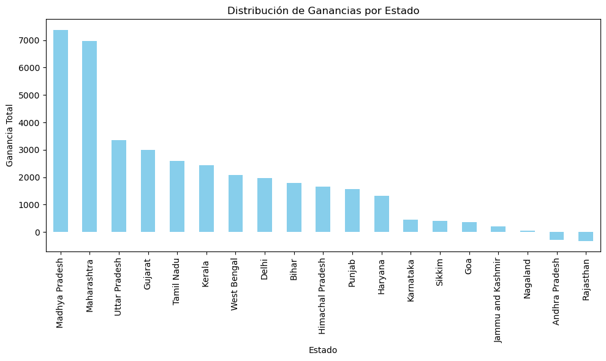

```python
import matplotlib.pyplot as plt

# Agrupando por estado y sumando las ganancias
profit_by_state = merged_df.groupby('State')['Profit'].sum().sort_values(ascending=False)

# Creación del gráfico de barras
plt.figure(figsize=(10,6))
profit_by_state.plot(kind='bar', color='skyblue')
plt.title('Distribución de Ganancias por Estado')
plt.xlabel('Estado')
plt.ylabel('Ganancia Total')
plt.xticks(rotation=90)
plt.tight_layout()
plt.show()
```

El gráfico de barras muestra las ganancias totales de cada estado, en este podemos observar a Madhya Pradesh con profit mayor a 7000 así como también observamos estamos como Andhra Pradesh y Rajasthan con profit menores a 0 lo cual puede significar perdidas

Gráfico de dispersión: Relación entre el monto de la venta y la ganancia

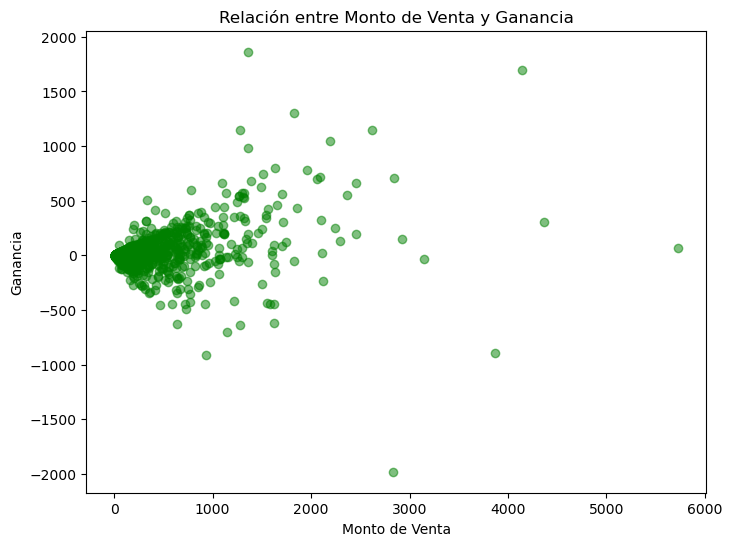

```python
plt.figure(figsize=(8,6))
plt.scatter(merged_df['Amount'], merged_df['Profit'], alpha=0.5, color='green')
plt.title('Relación entre Monto de Venta y Ganancia')
plt.xlabel('Monto de Venta')
plt.ylabel('Ganancia')
plt.show()
```

En este grafico se mostro la relación entre 'Amount' y 'Profit', por lo cual se concluye que existe una tendencia general de correlación positiva a mayor monto de venta mayores las ganancias, sin embargo también se observan hay varios puntos con ganancias cercanas a cero o incluso negativas para ventas con montos bajos y medios, esto indica que algunas ventas no estan generando beneficios significativos o incluso están resultando en pérdias.

Gráfico de torta: Proporción de categorías de productos vendidos

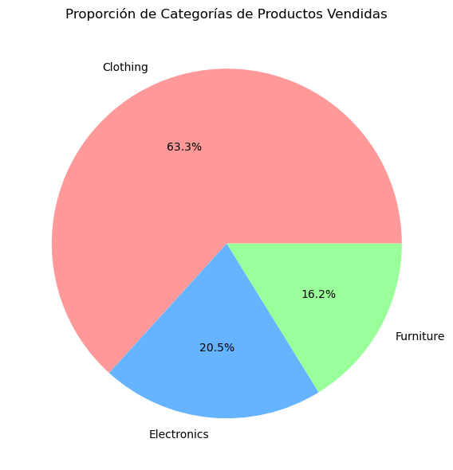

```python
category_distribution = merged_df['Category'].value_counts()

plt.figure(figsize=(8,6))
category_distribution.plot(kind='pie', autopct='%1.1f%%', colors=['#ff9999','#66b3ff','#99ff99'])
plt.title('Proporción de Categorías de Productos Vendidas')
plt.ylabel('')
plt.tight_layout()
plt.show()
```

Este gráfico muestra la distribución de las categorías de productos vendidas en el total de las transacciones, con este se concluye que la categoria 'Clothing' se muestra significativamente en las ventas, representando el 63.3%

Gráfico de barras: Cantidad de productos vendidos por método de pago

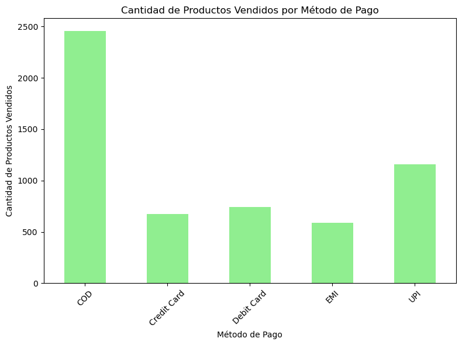

```python
payment_quantity = merged_df.groupby('PaymentMode')['Quantity'].sum()

plt.figure(figsize=(8,6))
payment_quantity.plot(kind='bar', color='lightgreen')
plt.title('Cantidad de Productos Vendidos por Método de Pago')
plt.xlabel('Método de Pago')
plt.ylabel('Cantidad de Productos Vendidos')
plt.xticks(rotation=45)
plt.tight_layout()
plt.show()
```

Este gráfico ilustra el número de productos vendidos según el método de pago utilizado por los clientes.

El método de pago con mayor número es el 'COD', con una cantidad significativa mayor a los 2000, además 'Credit Card', Debit Card', y 'EMI' tienen cantidades relativamente bajas en comparación con 'COD'.

### 8. Comentarios

- Relación entre ventas y ganancias: Aunque las ventas más altas tienden a generar más ganancias, no siempre es así. Es importante revisar las políticas que pueden generar perdidas en estas.
- Categorías de productos: La ropa es con diferencia la categoría con mayor número, aunque de igual forma se recomienda impulsar las demás categorías.
- Métodos de pago: Los clientes se encuentran en mayor número en los pagos con 'COD', lo que indica que es necesario fomentar el uso de pagos electrónicos para elevar estos números.